# Midterm inclass

Shane Hauck

3/9/2022

“All work presented is my own. I have not communicated with or worked with anyone else on this exam.” - Shane Hauck

Question 1 (20 points). Examine the following plot that uses the pokemon_full.csv data set. The plot gives the count of each Pokemon type.

```r
library(tidyverse)
library(here)
pokemon_df <- read_csv(here("data/pokemon_full.csv"))
```

```
## * `` -> ...1
```

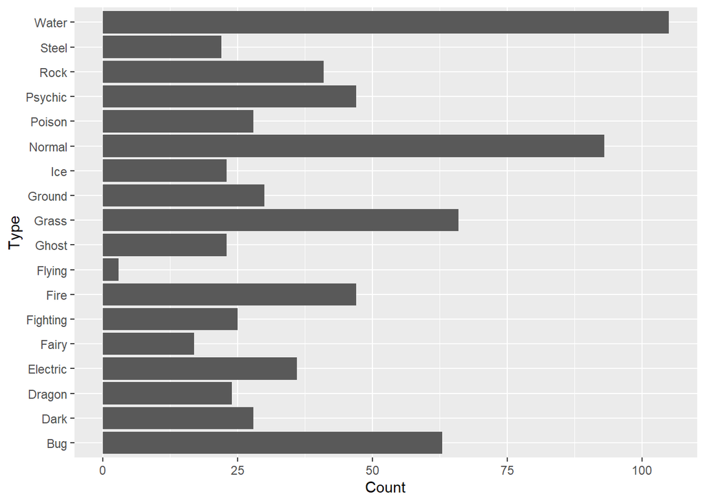

```r
pokemon_type <- pokemon_df %>% group_by(Type) %>% summarise(type_count = n())

ggplot(data = pokemon_type, aes(x = Type, y = type_count)) +
  geom_bar(stat = "identity") +
  labs(x = "Type",
       y = "Count") +
  coord_flip()
```

part a. Which of the 7 grammar of graphics parameters are explicitly specified in the code to make the plot?

(“stat =”identity”“)

part b. For these types of plots, we have usually reordered the Type so that the type with the most Pokemon would be first and the type with the least number of pokemon would be last. Use a principle from the Data Visualization Reading to explain why we would want to do this.

It is important to order you bar plots in a way that makes ordered sense because if you didn’t it would be of bad taste. When a view looks at a graph it should be easy to read and the viewer shouldn’t have to think to deeply about what the image is trying to tell you. By ordering the type of Pokemon in order of the most numbers to the least makes much more logical sense as the viewer can now easily see the trends of what types have the most and what types have the least.

part c. We have also stated that, for bar plots and lollipop plots, 0 should be included in the plot. On the other hand, for point plots and scatterplots, 0 need not be included. Using a principle from the Data Visualization Reading, explain why it is okay to omit 0 from a point plot but not from a bar plot.

When making plots, it is important to have honesty and good judgment as the creator of the plot. when thinking about where you should start your axis’, you should keep in mind the thought of how people view bar and dot plots conceptually. One could say that there is more to be in favor of showing the data over the range we observe it, rather than forcing every scale to encompass its lowest and highest theoretical value. Others would say that visualizations would be pointless if it was mandatory to include a zero point on the x or y axis. This shows how important it is to be honest and have good judgement because as the creator of the graph you could maliciously skew what the viewers see and their perception based on your decisions, and it is important not to do that.

Question 2 (5 points). These points will be given for properly committing and pushing a .Rmd and a .html file with your exam answers.

Question 3 (5 points). Tell me something you learned about ethics in data visualization.

Something I learned about ethics in data visualization is that the graphs you make can have a large influence on society and as a data scientist it is wrong to manipulate the graphs in a way that wrongfully portray the data. If a creator were to say have a political affiliation and create a graph in a way that a common person might not realize is tampered with, it could have drastic effects in the real world. It is you obligation as a creator of graphs to tell the absolute truth about the data, no matter the findings, while including everything in the graph that is necessary to show the data as it is.

Question 4 (20 points).

part a. A data set on United States election results was obtained from https://github.com/kjhealy/us_elections_2020_csv. Use the maps package, as well as this data set (posted on Sakai), to construct a map that fills each U.S. State with the percent of voters who voted for the republican candidate, Trump (percent_gop). For this problem,

- you do not need to worry about including Alaska or Hawaii. They are important but this is a timed exam!
- you should change the colour scale so that it is appropriate for the problem.

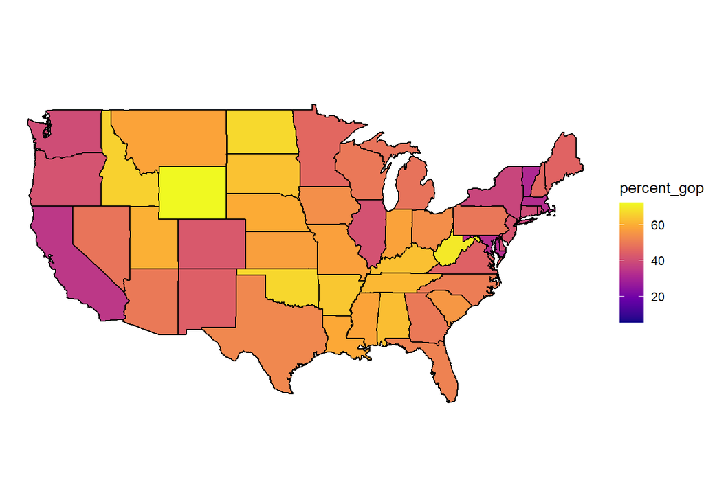

```r
library(maps)
library(tidyverse)
library(here)
election_df <- read_csv(here("data/2020_county_pres.csv")) %>%
  group_by(state_name) %>%
  summarise(total_gop = sum(votes_gop),
            total_dem = sum(votes_dem)) %>%
  mutate(percent_gop = 100 * total_gop / (total_gop + total_dem)) %>%
  mutate(state_name = str_to_lower(state_name))
state_df <- map_data("state")
state_election <- left_join(state_df, election_df, by = c("region" = "state_name"))

ggplot(state_election, aes(x = long, y = lat, group = group)) +
  geom_polygon(color = "black", aes(fill = percent_gop)) +
  coord_map() +
  theme_void() +
  scale_fill_viridis_c(option = "plasma")
```

part b. Explain why the data frame R needs to construct a map of the United States is much, much longer than 50 rows.

The data frame R needs to construct a map of the United States is much longer than 50 rows because it contains all of the necessary information for R to draw the polygon shapes of each state.

Question 5 (25 points). Construct a shiny app using the alcohol.csv data set that has a scatterplot of the number of wine servings vs. the number of beer servings. In the app, the user should be able to select a country and have a label for that country appear on the app.

In addition, create an input that lets the user choose a variable (either beer_servings, spirit_servings, and wine_servings) and create an output that is a histogram based on that variable.

So you can focus your time on shiny as much as possible, a static graph or wine servings vs. beer servings, with Australia labeled, is given below (you may copy this code to use in your app if you would like).

You must complete this task using shiny (even though you could do something similar using plotly).

```r
library(shiny)
library(tidyverse)
library(ggrepel)
library(here)
alcohol_df <- read_csv(here("data/alcohol.csv"))
```

```r
library(shiny)

ui <- fluidPage(
  sidebarLayout(
    sidebarPanel(selectInput("countrychoice", label = "Choose a Country",
                             choices = levels(factor(alcohol_df$country))),
                 radioButtons("varchoice", label = "Choose a Stat",
                             choices = names(alcohol_df)[2:4])),
    mainPanel(plotOutput("p_plot"),
              plotOutput("h_plot"))
  )
)

server <- function(input, output, session) {
  country_reactive_df <- reactive({
    df_stats <- alcohol_df %>% filter(country == input$countrychoice)
  })

  country_plot <- reactive({
    ggplot(alcohol_df, aes(x = beer_servings, y = wine_servings)) +
      geom_point() +
      geom_label_repel(data = country_reactive_df(), aes(label = country)) +
      geom_point(data = country_reactive_df(), size = 3, shape = 1)
  })

  var_plot <- reactive({
    ggplot(alcohol_df, aes(x = .data[[input$varchoice]])) +
      geom_histogram()
  })

  output$p_plot <- renderPlot({
    country_plot()
  })

  output$h_plot <- renderPlot({
    var_plot()
  })
}

shinyApp(ui, server)
```

```
## PhantomJS not found. You can install it with webshot::install_phantomjs(). If it is installed, please make sure the phantomjs executable can be found via the PATH variable.
```

Shiny applications not supported in static R Markdown documents

Question 6 (10 points). For the following shiny app, draw a reactive graph. I think the easiest way to do this would be to hand-draw the graph and hand it in on a piece of paper (there is paper at the front of the room). If you can figure out a way to draw it on your computer, you may do that and push that file to GitHub.

Check paper.

Question 7 (20 points). Consider again the women’s tennis data set, wta_matches_2019.csv, where each row corresponds to a match played on the WTA (Women’s Tennis Association) tour. Important variables to consider for this problem include:

winner_name, the name of the player who won the match loser_name, the name of the player who lost the match

Construct a lollipop chart that shows the 10 WTA tennis players with the highest average number of aces in the 2019 season who have played at least 20 matches.

Some Hints:

- if you can’t complete the task, make a lollipop chart of something to earn some partial credit.
- variables that you will need are winner_name, loser_name, w_ace, and l_ace.
- we haven’t done much in tidyr in class so I’ve already pivoted the data set for you (see code below).
- you will need to create a new variable called aces that is the w_ace if the player won (so if won_or_lost is winner_name) and l_ace if the player lost.
- recall that, if there are missing values, you will need to remove them when finding the mean aces for a player. You can do this with the na.rm = TRUE argument to your summarise() function. See https://highamm.github.io/datascience234/dplyr.html#removing-missing-values for a quick review of this.
- you will also need to count up the matches for each player and use a filtering join to only keep players who have played 20 or matches. As I’m writing this, I am realizing we did not do a ton with joins….so here is some code that may be helpful: semi_join(data_set_with_players_and_mean_aces, data_set_with_players_with_20_matches_or_more, by = c(“player” = “player”))

```r
library(tidyverse)
library(here)
wta_df <- read_csv("C:/Users/hauck/OneDrive/Desktop/Stat_405/STAT4005_Data_Viz/data/wta_matches_2019.csv")
wta_long <- wta_df %>% pivot_longer(c(winner_name, loser_name),
                                    names_to = "won_or_lost",
                                    values_to = "player") %>%
  select(won_or_lost, player, everything())
```

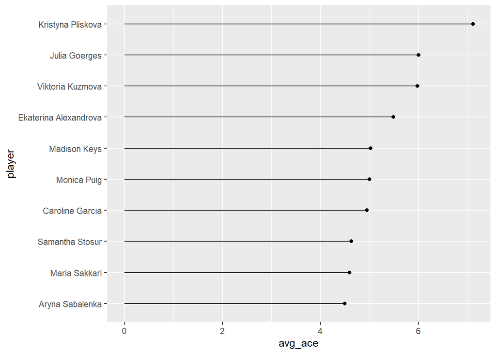

```r
plot_df <- wta_long %>% group_by(player) %>%
  mutate(total_matches = n()) %>%
  filter(total_matches >= 20) %>%
  mutate(num_ace = sum(w_ace)) %>%
  summarise(avg_ace = num_ace / total_matches) %>%
  distinct() %>%
  arrange(desc(avg_ace)) %>%
  ungroup() %>%
  mutate(rank = rank(desc(avg_ace))) %>%
  filter(rank <= 10) %>%
  mutate(player = fct_reorder(player, desc(rank)))
ggplot(plot_df, aes(x = player, y = avg_ace)) +
  geom_point() +
  geom_segment(aes(x = player, xend = player, y = 0, yend = avg_ace)) +
  coord_flip()
```

Question 8 (20 points).

part a. Consider the lollipop plot you made in Question 7. Why is this plot not the best plot to make to look at the top women’s servers in 2019? (There might be a couple of reasons but you should reference one that we have explicitly talked about in class a lot).

This would probably not be the best plot to make because it fails to show the variability of the dataset. Some of the players could have played a lot more matches than others or they could potentially have outliers that are skewing their data.

part b. Fix the plot so that it no longer has the issue you described in Question 8a. If you could not make the plot in Question 7, use this much simpler data set to plot the mean of yvar for each group and then fix the issue.

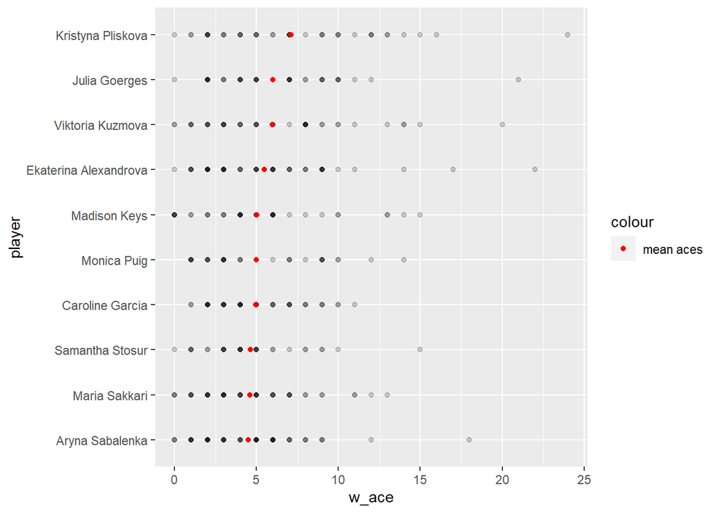

```r
plot_df2 <- left_join(plot_df, wta_long)
ggplot(plot_df2 %>% mutate(player = fct_reorder(player, desc(rank))), aes(x = player, y = w_ace)) +
  geom_point(alpha = 0.2) +
  geom_point(data = plot_df, aes(y = avg_ace, colour = "mean aces")) +
  coord_flip() +
  scale_colour_manual(values = c("mean aces" = "red"))
```